# Project 2

Ken Deng (s2617343)

# 1 Part 1: 3D printer

## 1.1 Question 1

We use 2 models to capture the relationship between **CAD_Weight** and **Actual_Weight**.

- Model A: $y_i = \beta_1 + \beta_2 x_i + \varepsilon_i$, where $\varepsilon_i \sim \mathcal{N}(0, \exp(\beta_3 + \beta_4 x_i))$.
- Model B: $y_i = \beta_1 + \beta_2 x_i + \varepsilon_i$, where $\varepsilon_i \sim \mathcal{N}(0, \exp(\beta_3) + \exp(\beta_4) x_i^2)$.

We use the observations to fit the model:
$$\hat{\boldsymbol{\beta}} = \text{argmin}_{\boldsymbol{\beta} \in
\mathbb{R}^4} -\ell (\boldsymbol{\beta}), \hat{\Sigma} = H^{-1},$$

where $H$ is Hessian Matrix.

For fitted value of observations, suppose $Z_E = \begin{bmatrix}1 \quad x \quad 0 \quad 0 \\ \vdots \quad \vdots \quad \vdots \quad \vdots \\ 1 \quad x \quad 0 \quad 0\end{bmatrix} \in \mathbb{R}^{86 \times 4}$:
$$\hat{\mu} = \hat{\beta}_1 + \hat{\beta}_2 x \\
\Rightarrow \hat{\mu} = Z_E \hat{\boldsymbol{\beta}} \text{ (in matrix)}$$

For estimated sigma of observations, suppose:

- Model A:$Z_V = \begin{bmatrix}0 \quad 0 \quad 1 \quad x \\ \vdots \quad \vdots \quad \vdots \quad \vdots \\ 0 \quad 0 \quad 1 \quad x\end{bmatrix} \in \mathbb{R}^{86 \times 4}$.
- Model B:$Z_V = \begin{bmatrix}0 \quad 0 \quad 1 \quad x^2 \\ \vdots \quad \vdots \quad \vdots \quad \vdots \\ 0 \quad 0 \quad 1 \quad x^2\end{bmatrix} \in \mathbb{R}^{86 \times 4}$.
  $$\hat{\sigma}^2_A = \exp(\hat{\beta}_3 + \hat{\beta}_4 x), \
  \hat{\sigma}^2_B = \exp(\hat{\beta}_3) + \exp(\hat{\beta}_4) x^2 \\
  \Rightarrow \hat{\sigma}^2_A = \exp(Z_V \hat{\boldsymbol{\beta}}),
  \hat{\sigma}^2_B = Z_V \exp(\hat{\boldsymbol{\beta}}) \text{ (in
  matrix)}$$

We now compute the predictive distribution for Model A and B. Let $y_{n+1}$ be new data, consider the distribution of $y_{n+1} - \hat{\mu}_{n+1}$:
$$y_{n+1} - \hat{\mu}_{n+1} \sim \mathcal{N} (0, \mathsf{Var} (y_{n+1} -
\hat{\mu}_{n+1})), \\
\text{where } \mathsf{Var} (y_{n+1} - \hat{\mu}_{n+1}) = \mathsf{Var}
(y_{n+1}) + \mathsf{Var} (\hat{\mu}_{n+1}) \quad (\text{by independent
of } \varepsilon \text{ and } \hat{\mu} ).$$

Based on the above analysis, we can compute 95% Prediction Interval(PI) for $y_{n+1}$:
$$\frac{y_{n+1} - \hat{\mu}_{n+1}}{\sqrt{\mathsf{Var}(y_{n+1} -
\hat{\mu}_{n+1})}} \sim \mathcal{N} (0, 1). \\
\text{95% PI: } \hat{\mu}_{n+1} \pm z_{0.975}
\sqrt{\mathsf{Var}(y_{n+1}) + \mathsf{Var}(\hat{\mu}_{n+1})}$$

According to the notation from Lecture 06, we represent the estimation uncertainty by a distribution of potential parameter values as follows:

The parameter vector $\boldsymbol{\beta}$ given the input vector $\boldsymbol{x}$ is assumed to follow a normal distribution:
$$\boldsymbol{\beta}|\boldsymbol{x} \sim
\mathcal{N}(\hat{\boldsymbol{\beta}}, \hat{\Sigma}),$$

where $\boldsymbol{\beta}|\boldsymbol{x}$ is treated as a random variable and $\hat{\boldsymbol{\beta}} \text{ and } \hat{\Sigma}$ are considered fixed values representing the estimated mean and covariance matrix respectively.

Hence we consider the prediction model:
$$y_{n+1} \sim \mathcal{N} (\hat{\mu}_{n+1}, \hat{\sigma}_{n+1}),$$

where $\hat{\sigma}_{n+1}$ is $\mathsf{E}(\mathsf{Var}(y_{n+1})) + \mathsf{Var}(\hat{\mu}_{n+1})$.

We now rewrite $\mathsf{E}(\mathsf{Var}(y_{n+1}))$ and $\mathsf{Var}(\hat{\mu}_{n+1})$ using $\boldsymbol{\beta}|\boldsymbol{x}$. Note that $Z_E = (1, x_{n+1}, 0, 0)$, $Z_V = \left\{\begin{matrix} (0, 0, 1, x_{n+1}) & \text{Model A} \\ (0, 0, 1, x_{n+1}^2) & \text{Model B} \end{matrix}\right.$.
$$\mathsf{Var}(\hat{\mu}_{n+1}) = \mathsf{Var} (\mathsf{E}
(Z_E\boldsymbol{\beta}|\boldsymbol{x})) =
Z_E\mathsf{Cov}(\boldsymbol{\beta}|\boldsymbol{x},
\boldsymbol{\beta}|\boldsymbol{x})Z_E^T = Z_E\hat{\Sigma}Z_E^T.$$

Note that if $x \sim \mathcal{N}(\mu, \sigma^2)$, then $\mathsf{E}(\exp(x)) = \exp(\mu + \sigma^2 / 2)$
$$\text{Model A: } \mathsf{E}(\mathsf{Var}(y_{n+1})) = \mathsf{E}(\exp(Z_V
\boldsymbol{\beta}|\boldsymbol{x})) = \exp(Z_V\hat{\boldsymbol{\beta}} +
Z_V\hat{\Sigma}Z_V^T / 2) \\
\text{Model B: } \mathsf{E}(\mathsf{Var}(y_{n+1})) = \mathsf{E}(Z_V
\exp(\boldsymbol{\beta}|\boldsymbol{x})) = Z_V
\exp(\hat{\boldsymbol{\beta}} + \text{diag}(\hat{\Sigma}) / 2).$$

Hence the prediction means, standard deviations, and 95% PI have the formula:
$$\hat{\mu}_{n+1} = Z_E \hat{\boldsymbol{\beta}}, \hat{\sigma}_{n+1} =
\mathsf{E}(\mathsf{Var}(y_{n+1})) + Z_E\hat{\Sigma}Z_E^T, \\
\text{95% PI: } \hat{\mu}_{n+1} \pm z_{0.975} \hat{\sigma}_{n+1}.$$

```r
pred_A <- filament1_predict(
  data = filament1,
  model = "A",
  newdata = filament1
)
```

| mean | sd | lwr | upr |
| --- | --- | --- | --- |
| 35.524602 | 0.9815810 | 33.600738 | 37.448465 |
| 43.079083 | 1.1941889 | 40.738516 | 45.419650 |
| 21.494851 | 0.6859387 | 20.150436 | 22.839266 |
| 47.395929 | 1.3366028 | 44.776236 | 50.015623 |
| 19.336428 | 0.6499262 | 18.062596 | 20.610260 |
| 3.148254 | 0.4460295 | 2.274052 | 4.022456 |

```r
pred_B <- filament1_predict(
  data = filament1,
  model = "B",
  newdata = filament1
)
```

| mean | sd | lwr | upr |
| --- | --- | --- | --- |
| 35.573228 | 1.2237897 | 33.17464 | 37.97181 |
| 43.153278 | 1.4836946 | 40.24529 | 46.06127 |
| 21.495990 | 0.7412875 | 20.04309 | 22.94889 |
| 47.484736 | 1.6322254 | 44.28563 | 50.68384 |
| 19.330261 | 0.6671021 | 18.02277 | 20.63776 |
| 3.087295 | 0.1149282 | 2.86204 | 3.31255 |

In general, both models demonstrate a satisfactory fitting effect, exhibiting prediction intervals that widen with increasing values of the independent variable, aligning well with our model hypothesis. Notably, we observe that model A exhibits greater uncertainty, particularly as the independent variable grows.

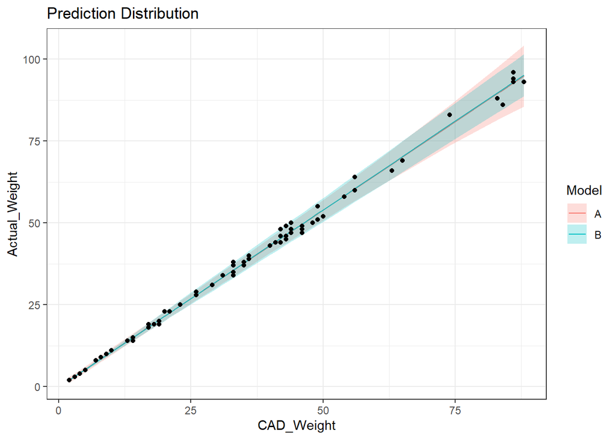

## 1.2 Question 2

We have the formula for computing Squared Error:
$$SE(y_{n+1}) = (y_{n+1} - \hat{\mu}_{n+1})^2$$

Anothoer formula for Dawid-Sebastiani score:
$$DS(y_{n+1}) = \frac{(y_{n+1} - \hat{\mu}_{n+1})^2}{\hat{\sigma}_{n+1}^2}
+ \log(\hat{\sigma}_{n+1}^2)$$

We now use `filament1_score` to compute the score for prediction.

For Model A:

```r
score_A <- filament1_score(
  data = filament1,
  model = "A",
  newdata = filament1
)
```

| Index | Date | Material | CAD_Weight | Actual_Weight | mean | sd | lwr | upr | se | ds |
| --- | --- | --- | --- | --- | --- | --- | --- | --- | --- | --- |
| 1 | 2017-12-29 | Neon pink | 33 | 38 | 35.524602 | 0.9815810 | 33.600738 | 37.448465 | 6.1275961 | 6.3225368 |
| 2 | 2017-12-29 | Green | 40 | 43 | 43.079083 | 1.1941889 | 40.738516 | 45.419650 | 0.0062541 | 0.3593200 |
| 3 | 2017-12-30 | Green | 20 | 23 | 21.494851 | 0.6859387 | 20.150436 | 22.839266 | 2.2654734 | 4.0609784 |
| 4 | 2017-12-30 | Green | 44 | 47 | 47.395929 | 1.3366028 | 44.776236 | 50.015623 | 0.1567601 | 0.6680090 |
| 5 | 2017-12-30 | Green | 18 | 19 | 19.336428 | 0.6499262 | 18.062596 | 20.610260 | 0.1131837 | -0.5938416 |
| 6 | 2017-12-30 | Green | 3 | 3 | 3.148254 | 0.4460295 | 2.274052 | 4.022456 | 0.0219792 | -1.5042600 |

For Model B:

```r
score_B <- filament1_score(
  data = filament1,
  model = "B",
  newdata = filament1
)
```

| Index | Date | Material | CAD_Weight | Actual_Weight | mean | sd | lwr | upr | se | ds |
| --- | --- | --- | --- | --- | --- | --- | --- | --- | --- | --- |
| 1 | 2017-12-29 | Neon pink | 33 | 38 | 35.573228 | 1.2237897 | 33.17464 | 37.97181 | 5.8892250 | 4.3361857 |
| 2 | 2017-12-29 | Green | 40 | 43 | 43.153278 | 1.4836946 | 40.24529 | 46.06127 | 0.0234943 | 0.7997433 |
| 3 | 2017-12-30 | Green | 20 | 23 | 21.495990 | 0.7412875 | 20.04309 | 22.94889 | 2.2620459 | 3.5177662 |
| 4 | 2017-12-30 | Green | 44 | 47 | 47.484736 | 1.6322254 | 44.28563 | 50.68384 | 0.2349690 | 1.0680850 |
| 5 | 2017-12-30 | Green | 18 | 19 | 19.330261 | 0.6671021 | 18.02277 | 20.63776 | 0.1090725 | -0.5645316 |
| 6 | 2017-12-30 | Green | 3 | 3 | 3.087295 | 0.1149282 | 2.86204 | 3.31255 | 0.0076204 | -3.7499619 |

Here we use the scatter plot to check the score of the predicted values.

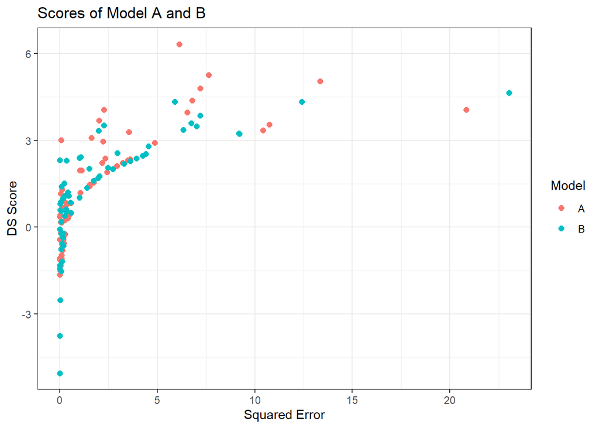

## 1.3 Question 3

### 1.3.1 leave-one-out Cross-Validation

For each prediction model $F_i$, we use $\{(x_j, y_j): j \ne i\}$ to fit.
$$\hat{\boldsymbol{\beta}}_i = \text{argmin}_{\boldsymbol{\beta} \in
\mathbb{R}^4} -\ell (\boldsymbol{\beta} ; y_1, \dots, y_{i-1}, y_{i+1},
\dots, y_n), \hat{\Sigma}_i = H_i^{-1}.$$

Then, we use fitted prediction model $F_i$ to predict new data $y_i$. Note that here the predict data in matrix is: $Z_E = (1, x_i, 0, 0)$, $Z_V = \left\{\begin{matrix} (0, 0, 1, x_{i}) & \text{Model A} \\ (0, 0, 1, x_{i}^2) & \text{Model B} \end{matrix}\right.$.

The leave-one-out prediction means, standard deviations, and prediction scores have the formula:
$$\hat{\mu}_i = Z_E \hat{\boldsymbol{\beta}}_i, \hat{\sigma}_i =
\mathsf{E}(\mathsf{Var}(y_{i})) + Z_E\hat{\Sigma}_iZ_E^T, \\
SE(y_i) = (y_{i} - \hat{\mu}_{i})^2, DS(y_i) = \frac{(y_{i} -
\hat{\mu}_{i})^2}{\hat{\sigma}_{i}^2} + \log(\hat{\sigma}_{i}^2).$$

For Model A:

```r
result_A.leave1out <- leave1out(
  data = filament1,
  model = "A"
)
```

| Index | Date | Material | CAD_Weight | Actual_Weight | mean | sd | se | ds |
| --- | --- | --- | --- | --- | --- | --- | --- | --- |
| 1 | 2017-12-29 | Neon pink | 33 | 38 | 35.481932 | 0.9483089 | 6.3406653 | 6.9445978 |
| 2 | 2017-12-29 | Green | 40 | 43 | 43.080638 | 1.2020610 | 0.0065025 | 0.3725753 |
| 3 | 2017-12-30 | Green | 20 | 23 | 21.471030 | 0.6566832 | 2.3377500 | 4.5799790 |
| 4 | 2017-12-30 | Green | 44 | 47 | 47.403825 | 1.3464938 | 0.1630749 | 0.6849534 |
| 5 | 2017-12-30 | Green | 18 | 19 | 19.342265 | 0.6555993 | 0.1171451 | -0.5718603 |
| 6 | 2017-12-30 | Green | 3 | 3 | 3.160504 | 0.4577106 | 0.0257616 | -1.4400688 |

For Model B:

```r
result_B.leave1out <- leave1out(
  data = filament1,
  model = "B"
)
```

| Index | Date | Material | CAD_Weight | Actual_Weight | mean | sd | se | ds |
| --- | --- | --- | --- | --- | --- | --- | --- | --- |
| 1 | 2017-12-29 | Neon pink | 33 | 38 | 35.540937 | 1.2015352 | 6.0469892 | 4.5557742 |
| 2 | 2017-12-29 | Green | 40 | 43 | 43.155126 | 1.4925115 | 0.0240640 | 0.8117232 |
| 3 | 2017-12-30 | Green | 20 | 23 | 21.477723 | 0.7270469 | 2.3173280 | 3.7463918 |
| 4 | 2017-12-30 | Green | 44 | 47 | 47.491432 | 1.6411577 | 0.2415056 | 1.0804695 |
| 5 | 2017-12-30 | Green | 18 | 19 | 19.334145 | 0.6701419 | 0.1116527 | -0.5519117 |
| 6 | 2017-12-30 | Green | 3 | 3 | 3.095113 | 0.1155359 | 0.0090465 | -3.6386310 |

We check the result of leave-one-out visually. The result shows that the fitting effect is quite good, and the prediction of the model has a slight deviation with the increase of independent variables.

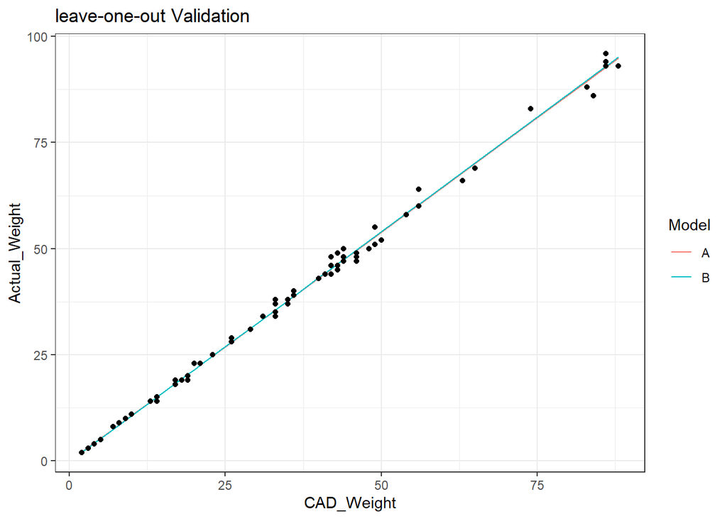

Subsequently, we examine the correlation between predicted scores and predictors. Notably, both scores exhibit a positive trend with increasing predictors, aligning with our model assumption.

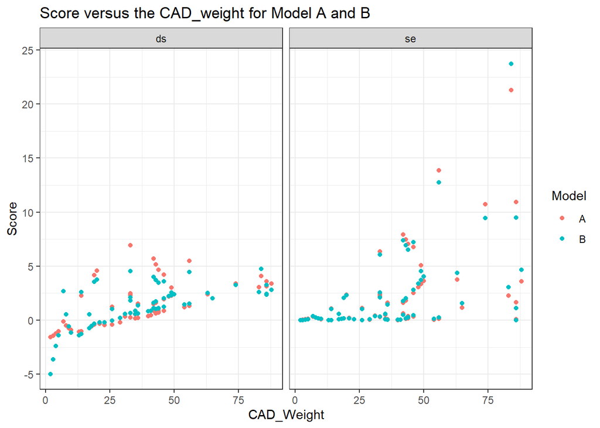

### 1.3.2 Average leave-one-out Score

For Model A, let $S(F_i^A, y_i)$ denote the score using prediction model $F_i$ on the new data $y_i$. Then, the average leave-one-out score $S_A$ has the formula:
$$S_A = \frac{1}{n}\sum_{i = 1}^n S(F_i^A, y_i)$$

Similarly, for Model B, the average leave-one-out score $S_B$ has the formula:
$$S_B = \frac{1}{n}\sum_{i = 1}^n S(F_i^B, y_i)$$

```r
result_summary <- result.leave1out %>%
  group_by(Model) %>%
  summarise(
    se = mean(se),
    ds = mean(ds)
  )
```

| Model | se | ds |
| --- | --- | --- |
| A | 1.841734 | 1.128348 |
| B | 1.841995 | 0.939715 |

Once again, we employ a scatter plot to examine the scores of the predicted values, highlighting the recently obtained averages.

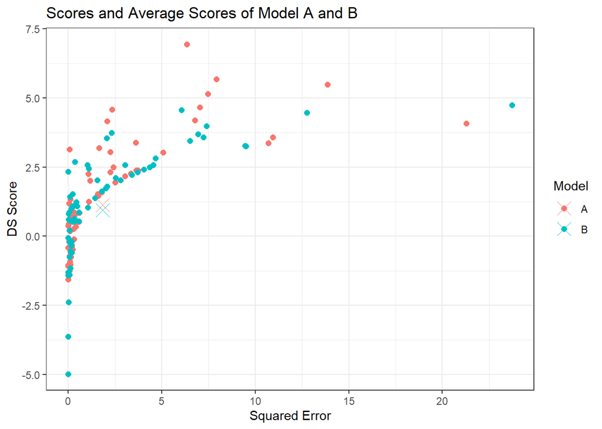

The results suggest that the mean square error of both models is comparable, indicating similar prediction accuracy between them. However, model B exhibits a smaller DS score. This reduction in DS score is attributed to the incorporation of variance alongside mean square error, highlighting the lower uncertainty associated with model B.

## 1.4 Question 4

### 1.4.1 Monte Carlo p-value Estimation

Our hypothesis for Model A and Model B is:
$$H_0: \text{A and B have pairwise exchangeability} \text{ v.s. } H_1:
\text{B is better than A}$$

For testing the average difference, we can use test statistic:
$$T = \frac{1}{n}\sum_{i=1}^{n} S_i^{\Delta},$$

where $S_i^{\Delta} = S(F_i^A, y_i) - S(F_i^B, y_i)$.

We now can use Monte Carlo Method to simulate the distribution of $T$. For each $j = 1, \dots, J$, we randomly swap the sign of $S_i^{\Delta}$, that is $\mathbb{P}\{S_i^{\Delta (j)} = S_i^{\Delta}\} = \mathbb{P}\{S_i^{\Delta (j)} = -S_i^{\Delta}\} = \frac{1}{2}$. We then compute test statistic:
$$T^{(j)} = \frac{1}{n}\sum_{i=1}^{n} S_i^{\Delta (j)}, j = 1, \dots, J.$$

According to the theory of Monte Carlo Probability Computation, we have an unbiased estimator of the p-value for testing our hypothesis:
$$\hat{p}_{value} = \frac{1}{J} \sum_{j = 1}^J \mathbb{1} \{ T^{(j)}
\ge T \}.$$

Let $J = 10000$.

```r
# S_Delta for each prediction
score_diff <- data.frame(
  se = result_A.leave1out$se - result_B.leave1out$se,
  ds = result_A.leave1out$ds - result_B.leave1out$ds
)

# test statistic
statistic0 <- score_diff %>%
  summarise(
    se = mean(se),
    ds = mean(ds)
  )

# sample number
J <- 10000

# sampling
statistic <- data.frame(
  se = numeric(J),
  ds = numeric(J)
)

for (loop in seq_len(J)) {
  random_sign <- sample(
    x = c(-1, 1),
    size = nrow(score_diff),
    replace = TRUE
  )
  statistic[loop, ] <- score_diff %>% summarise(
    se = mean(random_sign * se),
    ds = mean(random_sign * ds)
  )
}

# p-value computation
p_values <-
  statistic %>%
  summarise(
    se = mean(se > statistic0$se),
    ds = mean(ds > statistic0$ds)
  )
```

|  | se | ds |
| --- | --- | --- |
| p-value | 0.4989 | 0.0436 |

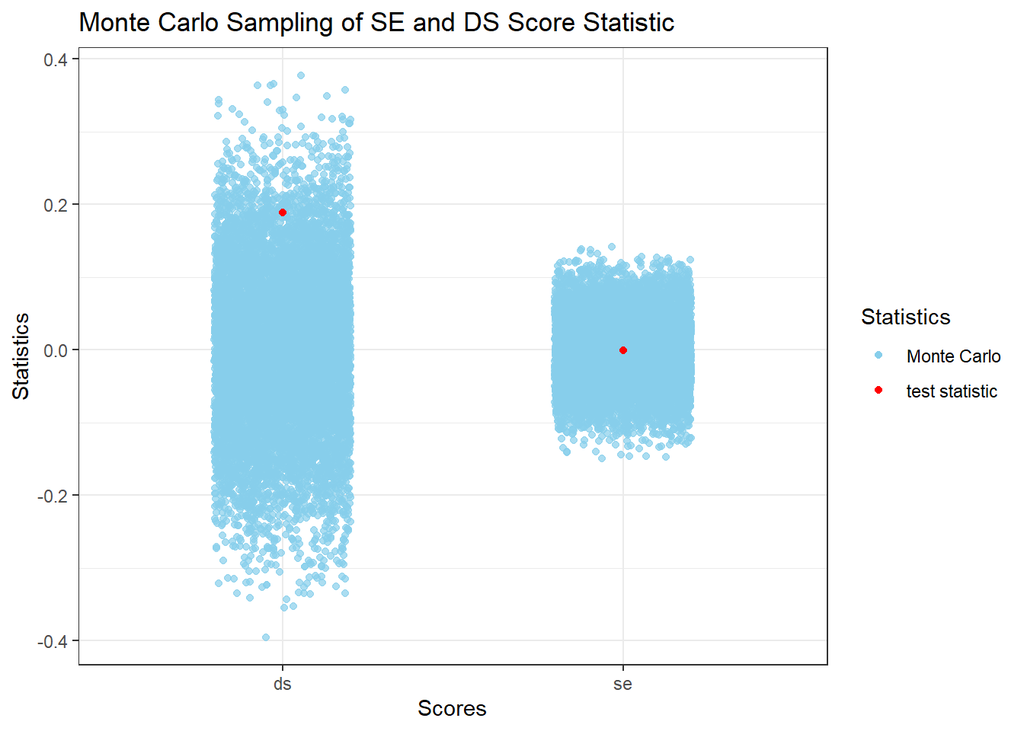

### 1.4.2 Monte Carlo Standard Error

Standard Error is the standard deviation of sample mean $\bar{X}$, then Monte Carlo standard error has the formula:
$$\hat{\sigma}_{\bar{X}} = \frac{\hat{\sigma}_X}{\sqrt{J}}$$

Monte Carlo Standard Error of test statistics $T$:

```r
standard.error.T <- data.frame(
  se = sd(statistic$se) / sqrt(J),
  ds = sd(statistic$ds) / sqrt(J)
)
```

|  | se | ds |
| --- | --- | --- |
| Standard Error | 0.0004726 | 0.0011228 |

Monte Carlo Standard Error of p-value estimator $p_{value}= \mathbb{1} \{ T^{(j)} \ge T \}$:

```r
standard.error.P <- data.frame(
  se = sd(statistic$se > statistic0$se) / sqrt(J),
  ds = sd(statistic$ds > statistic0$ds) / sqrt(J)
)
```

|  | se | ds |
| --- | --- | --- |
| Standard Error | 0.0050002 | 0.0020421 |

The small standard errors observed in both samples and p-value estimators generated by our Monte Carlo method suggest that our generated samples and p-value estimators closely resemble the population. This implies a high reliability of the obtained p-values.

Based on the p-value results for the squared errors of the two models, we infer that the two models exhibit pairwise exchangeability. However, when considering the DS scores, it appears that the performance of model B surpasses that of model A.

Taking into account the definitions of squared error and DS score, we can conclude that both model A and model B demonstrate similar levels of accuracy. Nonetheless, model B’s predictions exhibit higher certainty.

# 2 Part 2: Archaeology in the Baltic sea

## 2.1 Question 1

We assume that $Y$ is from Binominal distribution with parameters $N, \phi$:
$$Y \sim \text{Bino}(N, \phi), p_Y(y|N, \phi) = \left(\begin{matrix} N \\
y \end{matrix} \right) \phi^y (1 - \phi)^{N - y}.$$

Suppose we have 2 samples $y_1$ drawn from $Y_1$ and $y_2$ drawn from $Y_2$. Then, we can compute the log-likelihood given by parameters:
$$\begin{aligned}
\log [p(\boldsymbol{y}|N, \phi)] = \log [p(y_1, y_2|N, \phi)] = &
-\log \Gamma\left(y_{1}+1\right)-\log \Gamma\left(y_{2}+1\right) \\
& -\log \Gamma\left(N-y_{1}+1\right)-\log
\Gamma\left(N-y_{2}+1\right)+2 \log \Gamma(N+1) \\
& +\left(y_{1}+y_{2}\right) \log (\phi)+\left(2 N-y_{1}-y_{2}\right)
\log (1-\phi).
\end{aligned}$$

Hence we have the prior distribution:
$$\begin{aligned}
p_{N}(n)=\mathrm{P}(N=n) & =\xi(1-\xi)^{n}, \quad \xi =
\frac{1}{1001}, n=0,1,2,3, \ldots, \\
p_{\phi}(\phi) & =\frac{\phi^{a-1}(1-\phi)^{b-1}}{B(a, b)}, \quad a
= 2, b = 2, \phi \in[0,1] .
\end{aligned}$$

Note that we have the observations $\boldsymbol{y} = (256, 237)$ and let sample number $k = 100$:

```r
# sample number
k <- 100

# sampling
N.sample <- rgeom(n = k, prob = 1 / (1001))
Phi.sample <- rbeta(n = k, shape1 = 2, shape2 = 2)
params <- data.frame(
  N = N.sample,
  Phi = Phi.sample
)

# loglike
loglike <- arch_loglike(
  y = c(256, 237),
  params = params
)
```

| N | Phi | loglike |
| --- | --- | --- |
| 872 | 0.7769891 | -970.5908 |
| 1 | 0.7757799 | -Inf |
| 203 | 0.2276955 | -Inf |
| 2407 | 0.4452795 | -1362.5515 |
| 2523 | 0.2449088 | -365.5170 |
| 1731 | 0.4507126 | -762.3259 |

## 2.2 Question 2

Note that the posterior probability function for $(N, \phi \mid y)$ is:
$$p_{N, \phi \mid \boldsymbol{Y}}(n, \phi \mid \boldsymbol{y}) =
\frac{p_{N, \phi, \boldsymbol{Y}}(n, \phi,
\boldsymbol{y})}{p_{\boldsymbol{Y}}(\boldsymbol{y})} =
\frac{p_{N}(n) p_{\phi}(\phi) p(\boldsymbol{y} \mid n,
\phi)}{p_{\boldsymbol{Y}}(\boldsymbol{y})}.$$

Consider the prior distributions as sampling distributions, then the samples can be used to compute Monte Carlo estimations:
$$\begin{aligned}
\widehat{p}_{\boldsymbol{Y}}(\boldsymbol{y}) & =\frac{1}{K}
\sum_{k=1}^{K} p\left(\boldsymbol{y} \mid n^{[k]}, \phi^{[k]}\right) \\
\widehat{\mathrm{E}}(N \mid \boldsymbol{y}) & =\frac{1}{K
\widehat{p}_{\boldsymbol{Y}}(\boldsymbol{y})} \sum_{k=1}^{K} n^{[k]}
p\left(\boldsymbol{y} \mid n^{[k]}, \phi^{[k]}\right) \\
\widehat{\mathrm{E}}(\phi \mid \boldsymbol{y}) & =\frac{1}{K
\widehat{p}_{\boldsymbol{Y}}(\boldsymbol{y})} \sum_{k=1}^{K} \phi^{[k]}
p\left(\boldsymbol{y} \mid n^{[k]}, \phi^{[k]}\right)
\end{aligned}$$

```r
MC.estimation <- estimate(
  y = c(256, 237),
  xi = 1 / 1001,
  a = 0.5, b = 0.5,
  K = 10000
)
```

| p.y | E.N_y | E.Phi_y |
| --- | --- | --- |
| 8.3e-06 | 860.7398 | 0.426275 |

It’s important to note that the value of the density function holds no practical significance, as its estimator primarily serves as an expectation used for estimating the posterior distribution of two parameters.

# 3 Code appendix

```r
#' Ken Deng, s2617343
#' Add your own function definitions on this file.

#' neg_log_lik
#
#' @description Evaluate the negated log-likelihood for model A and B
#' @param beta A vector with the beta parameters
#' @param data A `data.frame` with the same variables as the `filament1` data set.
#' Must have columns `CAD_Weight` and `Actual_Weight`
#' @param model Either "A" for a log-linear variance model, or "B" for a proportional
#' scaling error model

neg_log_lik <- function(beta, data, model) {
  mu <- beta[1] + beta[2] * data[["CAD_Weight"]]

  # distinguish between the two models to find the particular standard deviation for the betas
  if (model == "A") {
    sigma <- sqrt(exp(beta[3] + beta[4] * data[["CAD_Weight"]]))
  } else {
    sigma <- sqrt(exp(beta[3]) + exp(beta[4]) * (data[["CAD_Weight"]]^2))
  }
  -sum(dnorm(data[["Actual_Weight"]],
    mean = mu,
    sd = sigma,
    log = TRUE
  ))
}

#' filament_estimate
#
#' @description Estimate filament models with different variance structure
#' @param data A `data.frame` with the same variables as the `filament1` data set.
#' Must have columns `CAD_Weight` and `Actual_Weight`
#' @param model Either "A" for a log-linear variance model, or "B" for a proportional
#' scaling error model
#' @return An estimation object suitable for use with [filament1_predict()]

filament1_estimate <- function(data, model) {
  model <- match.arg(model, c("A", "B"))
  if (model == "A") {
    beta_start <- c(-0.1, 1.07, -2, 0.05)
  } else {
    beta_start <- c(-0.15, 1.07, -13.5, -6.5)
  }
  opt <- optim(beta_start,
    neg_log_lik,
    data = data,
    model = model,
    hessian = TRUE,
    method = "Nelder-Mead",
    control = list(maxit = 5000)
  )
  fit <- list(
    model = model,
    par = opt$par,
    hessian = opt$hessian
  )
  class(fit) <- c("filament1_estimate", "list")
  fit # betahat and SEbetahat
}

#' filament1_aux_EV
#'
#' @description Evaluate the expectation and variance for model A and B
#' @param beta A vector with the beta parameters
#' @param data A `data.frame` containing the required predictors, including `CAD_Weight`
#' @param model Either "A" for a log-linear variance model, or "B" for a proportional
#' scaling error model
#' @param Sigma_beta : If not NULL, an estimate of the covariance matrix for
#                 the uncertainty of estimated betas
#' @return A list with four elements:
#     E : E(y|beta,x)
#     V : Var(y|beta,x)
#     VE : Var(E(y|beta,x)|x) or NULL
#     EV : E(Var(y|beta,x)|x) or NULL

filament1_aux_EV <- function(beta, data, model = c("A", "B"),
                             Sigma_beta = NULL) {
  model <- match.arg(model)
  if (model == "A") {
    ZE.0 <- model.matrix(~ 1 + CAD_Weight, data = data)
    ZV.0 <- model.matrix(~ 1 + CAD_Weight, data = data)
    ZE <- cbind(ZE.0, ZV.0 * 0)
    ZV <- cbind(ZE.0 * 0, ZV.0)

    VE <- EV <- NULL
    if (!is.null(Sigma_beta)) {
      # E(Var(y|beta,x)|x)
      EV <- exp(ZV %*% beta + rowSums(ZV * (ZV %*% Sigma_beta)) / 2)
      # Var(E(y|beta,x)|x)
      VE <- rowSums(ZE * (ZE %*% Sigma_beta))
    }
    out <- list(
      E = ZE %*% beta, # [X, 0] %*% betahat --- muhat_i
      V = exp(ZV %*% beta), # exp([0, X] %*% betahat) --- sigmahat_i residual variance
      VE = VE,
      EV = EV
    )
  } else { # model B

    ZE.0 <- model.matrix(~ 1 + CAD_Weight, data = data) # X
    ZV.0 <- model.matrix(~ 1 + I(CAD_Weight^2), data = data) # X
    ZE <- cbind(ZE.0, ZV.0 * 0)
    ZV <- cbind(ZE.0 * 0, ZV.0)

    VE <- EV <- NULL
    if (!is.null(Sigma_beta)) {
      # E(Var(y|beta,x)|x)
      # (pmin: Ignore large Sigma_beta values)
      EV <- ZV %*% exp(beta + pmin(0.5^2, diag(Sigma_beta)) / 2)
      # Var(E(y|beta,x)|x)
      VE <- rowSums(ZE * (ZE %*% Sigma_beta))
    }
    out <- list(
      E = ZE %*% beta,
      V = ZV %*% exp(beta),
      VE = VE,
      EV = EV
    )
  }
  out # hat E() and hat Var(), hat Var() of hat mu for each y_i
}

#' filament1_predict
#'
#' @description Evaluate the prediction means, standard deviations, and 95% PI
#' @param data train data
#' @param model the linear Model A or B
#' @param newdata test data
#' @return data.frame with mean, sd, lower bound, upper bound for test data

filament1_predict <- function(data, model, newdata) {
  # fit the model
  fit0 <- filament1_estimate(data = data, model = model)
  # prediction on test data
  pred0 <- filament1_aux_EV(
    beta = fit0$par,
    data = newdata,
    model = model,
    Sigma_beta = solve(fit0$hessian)
  )

  # prediction distribution
  mean <- pred0$E
  sd <- sqrt(pred0$EV + pred0$VE)
  q <- qt(1 - 0.05 / 2, df = Inf)
  lwr <- mean - q * sd
  upr <- mean + q * sd

  # return
  data.frame(
    mean = mean, sd = sd,
    lwr = lwr, upr = upr
  )
}

#' filament1_score
#'
#' @description Evaluate the squared error (ES) and Dawid-Sebastiani (DS) scores.
#' @param data train data
#' @param model the linear Model A or B
#' @param newdata test data
#' @return data.frame that extends the original data frame with additional columns:
#'         mean, sd, lower bound, upper bound, se and ds of prediction distribution and prediction scores.

filament1_score <- function(data, model, newdata) {
  # fit the model and predict the test data
  pred <- filament1_predict(
    data = data,
    model = model,
    newdata = newdata
  )

  # calculate the score for each prediction
  result <- cbind(newdata, pred) %>%
    mutate(
      se = (Actual_Weight - mean)^2,
      ds = (Actual_Weight - mean)^2 / sd^2 + 2 * log(sd)
    )

  # return
  result
}

#' leave1out
#'
#' @description leave-one-out cross-validation for the selected model for each observation
#' @param data dataset
#' @param model model the linear Model A or B
#' @return data.frame that extends the original data frame with four additional columns:
#'         mean, sd, se and ds of leave-one-out prediction means, standard deviations, and prediction scores.

leave1out <- function(data, model) {
  n <- nrow(data)
  mean <- numeric(n)
  sd <- numeric(n)

  for (i in 1:n) {
    # train data
    leave_1_out_data <- data[-i, ]

    # fit the model and predict the test data
    fit0 <- filament1_estimate(
      data = leave_1_out_data,
      model = model
    )
    pred0 <- filament1_aux_EV(
      beta = fit0$par,
      data = data[i, ],
      model = model,
      Sigma_beta = solve(fit0$hessian)
    )

    # prediction distribution
    mean[i] <- pred0$E
    sd[i] <- sqrt(pred0$EV + pred0$VE)
  }

  pred.dist <- data.frame(
    mean = mean, sd = sd
  )

  result <- cbind(data, pred.dist) %>%
    mutate(
      se = (Actual_Weight - mean)^2,
      ds = (Actual_Weight - mean)^2 / (sd)^2 + 2 * log(sd)
    )

  # return
  result
}

#' arch_loglike
#'
#' @description Evaluates the combined log-likelihood for a collection y-observations.
#' @param y y-observations
#' @param params data.frame with columns samples N and phi
#' @return the log-likelihood for each row-pair (N, phi)

arch_loglike <- function(y, params) {
  y1 <- y[1]
  y2 <- y[2]
  N <- params$N
  Phi <- params$Phi

  # return loglike
  -lgamma(y1 + 1) - lgamma(y2 + 1) - lgamma(N - y1 + 1) - lgamma(N - y2 + 1) +
    2 * lgamma(N + 1) + (y1 + y2) * log(Phi) + (2 * N - y1 - y2) * log(1 - Phi)
}

#' estimate
#'
#' @description Monte Carlo integration method to approximate p(y), E(N|y), and E(phi|y).
#' @param y y-observations
#' @param xi parameter of N prior distribution
#' @param a parameter of phi prior distribution
#' @param b parameter of phi prior distribution
#' @param K number of samples
#' @return estimations for p(y), E(N|y), and E(phi|y)

estimate <- function(y, xi, a, b, K) {
  # sampling
  N <- rgeom(n = K, prob = xi)
  Phi <- rbeta(n = K, shape1 = a, shape2 = b)
  params <- data.frame(N = N, Phi = Phi)
  likelihood <- exp(arch_loglike(y = y, params = params))

  # compute estimation
  density_y <- 1 / (K) * (sum(likelihood))
  expectation_N <- 1 / (K * density_y) * (sum(N * likelihood))
  expectation_Phi <- 1 / (K * density_y) * (sum(Phi * likelihood))

  # return
  data.frame(p.y = density_y, E.N_y = expectation_N, E.Phi_y = expectation_Phi)
}
```

# Project 2

Ken Deng (s2617343)

# 1 Part 1: 3D printer

## 1.1 Question 1

We use 2 models to capture the relationship between **CAD_Weight** and **Actual_Weight**.

- Model A: $y_i = \beta_1 + \beta_2 x_i + \varepsilon_i$, where $\varepsilon_i \sim \mathcal{N}(0, \exp(\beta_3 + \beta_4 x_i))$.
- Model B: $y_i = \beta_1 + \beta_2 x_i + \varepsilon_i$, where $\varepsilon_i \sim \mathcal{N}(0, \exp(\beta_3) + \exp(\beta_4) x_i^2)$.

We use the observations to fit the model:
$$\hat{\boldsymbol{\beta}} = \text{argmin}_{\boldsymbol{\beta} \in
\mathbb{R}^4} -\ell (\boldsymbol{\beta}), \hat{\Sigma} = H^{-1},$$

where $H$ is Hessian Matrix.

For fitted value of observations, suppose $Z_E = \begin{bmatrix}1 \quad x \quad 0 \quad 0 \\ \vdots \quad \vdots \quad \vdots \quad \vdots \\ 1 \quad x \quad 0 \quad 0\end{bmatrix} \in \mathbb{R}^{86 \times 4}$:
$$\hat{\mu} = \hat{\beta}_1 + \hat{\beta}_2 x \\
\Rightarrow \hat{\mu} = Z_E \hat{\boldsymbol{\beta}} \text{ (in matrix)}$$

For estimated sigma of observations, suppose:

- Model A:$Z_V = \begin{bmatrix}0 \quad 0 \quad 1 \quad x \\ \vdots \quad \vdots \quad \vdots \quad \vdots \\ 0 \quad 0 \quad 1 \quad x\end{bmatrix} \in \mathbb{R}^{86 \times 4}$.
- Model B:$Z_V = \begin{bmatrix}0 \quad 0 \quad 1 \quad x^2 \\ \vdots \quad \vdots \quad \vdots \quad \vdots \\ 0 \quad 0 \quad 1 \quad x^2\end{bmatrix} \in \mathbb{R}^{86 \times 4}$.
  $$\hat{\sigma}^2_A = \exp(\hat{\beta}_3 + \hat{\beta}_4 x), \
  \hat{\sigma}^2_B = \exp(\hat{\beta}_3) + \exp(\hat{\beta}_4) x^2 \\
  \Rightarrow \hat{\sigma}^2_A = \exp(Z_V \hat{\boldsymbol{\beta}}),
  \hat{\sigma}^2_B = Z_V \exp(\hat{\boldsymbol{\beta}}) \text{ (in
  matrix)}$$

We now compute the predictive distribution for Model A and B. Let $y_{n+1}$ be new data, consider the distribution of $y_{n+1} - \hat{\mu}_{n+1}$:
$$y_{n+1} - \hat{\mu}_{n+1} \sim \mathcal{N} (0, \mathsf{Var} (y_{n+1} -
\hat{\mu}_{n+1})), \\
\text{where } \mathsf{Var} (y_{n+1} - \hat{\mu}_{n+1}) = \mathsf{Var}
(y_{n+1}) + \mathsf{Var} (\hat{\mu}_{n+1}) \quad (\text{by independent
of } \varepsilon \text{ and } \hat{\mu} ).$$

Based on the above analysis, we can compute 95% Prediction Interval(PI) for $y_{n+1}$:
$$\frac{y_{n+1} - \hat{\mu}_{n+1}}{\sqrt{\mathsf{Var}(y_{n+1} -
\hat{\mu}_{n+1})}} \sim \mathcal{N} (0, 1). \\
\text{95% PI: } \hat{\mu}_{n+1} \pm z_{0.975}
\sqrt{\mathsf{Var}(y_{n+1}) + \mathsf{Var}(\hat{\mu}_{n+1})}$$

According to the notation from Lecture 06, we represent the estimation uncertainty by a distribution of potential parameter values as follows:

The parameter vector $\boldsymbol{\beta}$ given the input vector $\boldsymbol{x}$ is assumed to follow a normal distribution:
$$\boldsymbol{\beta}|\boldsymbol{x} \sim
\mathcal{N}(\hat{\boldsymbol{\beta}}, \hat{\Sigma}),$$

where $\boldsymbol{\beta}|\boldsymbol{x}$ is treated as a random variable and $\hat{\boldsymbol{\beta}} \text{ and } \hat{\Sigma}$ are considered fixed values representing the estimated mean and covariance matrix respectively.

Hence we consider the prediction model:
$$y_{n+1} \sim \mathcal{N} (\hat{\mu}_{n+1}, \hat{\sigma}_{n+1}),$$

where $\hat{\sigma}_{n+1}$ is $\mathsf{E}(\mathsf{Var}(y_{n+1})) + \mathsf{Var}(\hat{\mu}_{n+1})$.

We now rewrite $\mathsf{E}(\mathsf{Var}(y_{n+1}))$ and $\mathsf{Var}(\hat{\mu}_{n+1})$ using $\boldsymbol{\beta}|\boldsymbol{x}$. Note that $Z_E = (1, x_{n+1}, 0, 0)$, $Z_V = \left\{\begin{matrix} (0, 0, 1, x_{n+1}) & \text{Model A} \\ (0, 0, 1, x_{n+1}^2) & \text{Model B} \end{matrix}\right.$.
$$\mathsf{Var}(\hat{\mu}_{n+1}) = \mathsf{Var} (\mathsf{E}
(Z_E\boldsymbol{\beta}|\boldsymbol{x})) =
Z_E\mathsf{Cov}(\boldsymbol{\beta}|\boldsymbol{x},
\boldsymbol{\beta}|\boldsymbol{x})Z_E^T = Z_E\hat{\Sigma}Z_E^T.$$

Note that if $x \sim \mathcal{N}(\mu, \sigma^2)$, then $\mathsf{E}(\exp(x)) = \exp(\mu + \sigma^2 / 2)$
$$\text{Model A: } \mathsf{E}(\mathsf{Var}(y_{n+1})) = \mathsf{E}(\exp(Z_V
\boldsymbol{\beta}|\boldsymbol{x})) = \exp(Z_V\hat{\boldsymbol{\beta}} +
Z_V\hat{\Sigma}Z_V^T / 2) \\
\text{Model B: } \mathsf{E}(\mathsf{Var}(y_{n+1})) = \mathsf{E}(Z_V
\exp(\boldsymbol{\beta}|\boldsymbol{x})) = Z_V
\exp(\hat{\boldsymbol{\beta}} + \text{diag}(\hat{\Sigma}) / 2).$$

Hence the prediction means, standard deviations, and 95% PI have the formula:
$$\hat{\mu}_{n+1} = Z_E \hat{\boldsymbol{\beta}}, \hat{\sigma}_{n+1} =
\mathsf{E}(\mathsf{Var}(y_{n+1})) + Z_E\hat{\Sigma}Z_E^T, \\
\text{95% PI: } \hat{\mu}_{n+1} \pm z_{0.975} \hat{\sigma}_{n+1}.$$

```r
pred_A <- filament1_predict(
  data = filament1,
  model = "A",
  newdata = filament1
)
```

| mean | sd | lwr | upr |
| --- | --- | --- | --- |
| 35.524602 | 0.9815810 | 33.600738 | 37.448465 |
| 43.079083 | 1.1941889 | 40.738516 | 45.419650 |
| 21.494851 | 0.6859387 | 20.150436 | 22.839266 |
| 47.395929 | 1.3366028 | 44.776236 | 50.015623 |
| 19.336428 | 0.6499262 | 18.062596 | 20.610260 |
| 3.148254 | 0.4460295 | 2.274052 | 4.022456 |

```r
pred_B <- filament1_predict(
  data = filament1,
  model = "B",
  newdata = filament1
)
```

| mean | sd | lwr | upr |
| --- | --- | --- | --- |
| 35.573228 | 1.2237897 | 33.17464 | 37.97181 |
| 43.153278 | 1.4836946 | 40.24529 | 46.06127 |
| 21.495990 | 0.7412875 | 20.04309 | 22.94889 |
| 47.484736 | 1.6322254 | 44.28563 | 50.68384 |
| 19.330261 | 0.6671021 | 18.02277 | 20.63776 |
| 3.087295 | 0.1149282 | 2.86204 | 3.31255 |

In general, both models demonstrate a satisfactory fitting effect, exhibiting prediction intervals that widen with increasing values of the independent variable, aligning well with our model hypothesis. Notably, we observe that model A exhibits greater uncertainty, particularly as the independent variable grows.

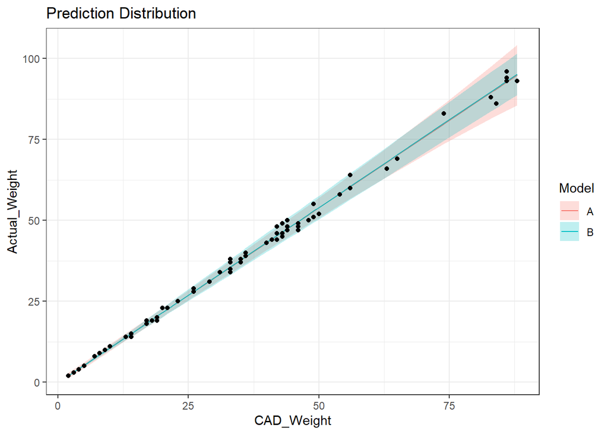

## 1.2 Question 2

We have the formula for computing Squared Error:
$$SE(y_{n+1}) = (y_{n+1} - \hat{\mu}_{n+1})^2$$

Anothoer formula for Dawid-Sebastiani score:
$$DS(y_{n+1}) = \frac{(y_{n+1} - \hat{\mu}_{n+1})^2}{\hat{\sigma}_{n+1}^2}
+ \log(\hat{\sigma}_{n+1}^2)$$

We now use `filament1_score` to compute the score for prediction.

For Model A:

```r
score_A <- filament1_score(
  data = filament1,
  model = "A",
  newdata = filament1
)
```

| Index | Date | Material | CAD_Weight | Actual_Weight | mean | sd | lwr | upr | se | ds |
| --- | --- | --- | --- | --- | --- | --- | --- | --- | --- | --- |
| 1 | 2017-12-29 | Neon pink | 33 | 38 | 35.524602 | 0.9815810 | 33.600738 | 37.448465 | 6.1275961 | 6.3225368 |
| 2 | 2017-12-29 | Green | 40 | 43 | 43.079083 | 1.1941889 | 40.738516 | 45.419650 | 0.0062541 | 0.3593200 |
| 3 | 2017-12-30 | Green | 20 | 23 | 21.494851 | 0.6859387 | 20.150436 | 22.839266 | 2.2654734 | 4.0609784 |
| 4 | 2017-12-30 | Green | 44 | 47 | 47.395929 | 1.3366028 | 44.776236 | 50.015623 | 0.1567601 | 0.6680090 |
| 5 | 2017-12-30 | Green | 18 | 19 | 19.336428 | 0.6499262 | 18.062596 | 20.610260 | 0.1131837 | -0.5938416 |
| 6 | 2017-12-30 | Green | 3 | 3 | 3.148254 | 0.4460295 | 2.274052 | 4.022456 | 0.0219792 | -1.5042600 |

For Model B:

```r
score_B <- filament1_score(
  data = filament1,
  model = "B",
  newdata = filament1
)
```

| Index | Date | Material | CAD_Weight | Actual_Weight | mean | sd | lwr | upr | se | ds |
| --- | --- | --- | --- | --- | --- | --- | --- | --- | --- | --- |
| 1 | 2017-12-29 | Neon pink | 33 | 38 | 35.573228 | 1.2237897 | 33.17464 | 37.97181 | 5.8892250 | 4.3361857 |
| 2 | 2017-12-29 | Green | 40 | 43 | 43.153278 | 1.4836946 | 40.24529 | 46.06127 | 0.0234943 | 0.7997433 |
| 3 | 2017-12-30 | Green | 20 | 23 | 21.495990 | 0.7412875 | 20.04309 | 22.94889 | 2.2620459 | 3.5177662 |
| 4 | 2017-12-30 | Green | 44 | 47 | 47.484736 | 1.6322254 | 44.28563 | 50.68384 | 0.2349690 | 1.0680850 |
| 5 | 2017-12-30 | Green | 18 | 19 | 19.330261 | 0.6671021 | 18.02277 | 20.63776 | 0.1090725 | -0.5645316 |
| 6 | 2017-12-30 | Green | 3 | 3 | 3.087295 | 0.1149282 | 2.86204 | 3.31255 | 0.0076204 | -3.7499619 |

Here we use the scatter plot to check the score of the predicted values.

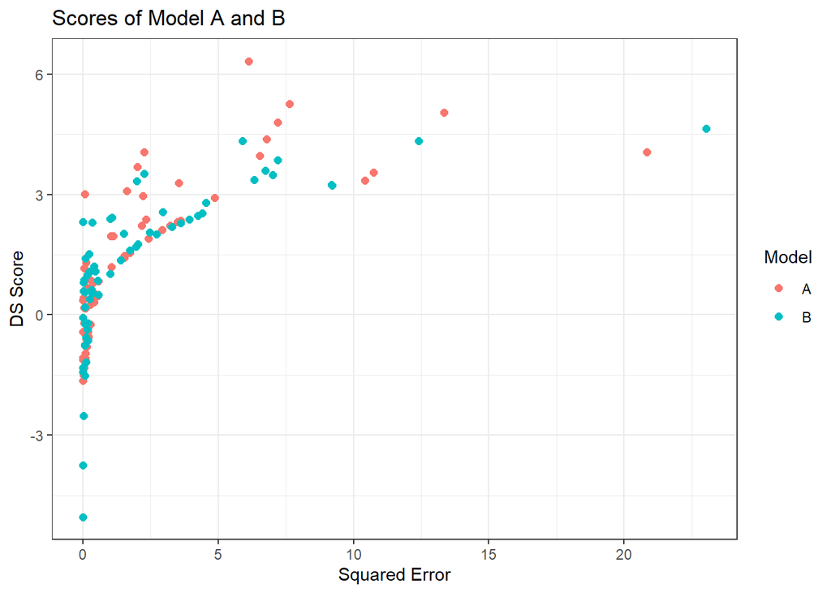

## 1.3 Question 3

### 1.3.1 leave-one-out Cross-Validation

For each prediction model $F_i$, we use $\{(x_j, y_j): j \ne i\}$ to fit.
$$\hat{\boldsymbol{\beta}}_i = \text{argmin}_{\boldsymbol{\beta} \in
\mathbb{R}^4} -\ell (\boldsymbol{\beta} ; y_1, \dots, y_{i-1}, y_{i+1},
\dots, y_n), \hat{\Sigma}_i = H_i^{-1}.$$

Then, we use fitted prediction model $F_i$ to predict new data $y_i$. Note that here the predict data in matrix is: $Z_E = (1, x_i, 0, 0)$, $Z_V = \left\{\begin{matrix} (0, 0, 1, x_{i}) & \text{Model A} \\ (0, 0, 1, x_{i}^2) & \text{Model B} \end{matrix}\right.$.

The leave-one-out prediction means, standard deviations, and prediction scores have the formula:
$$\hat{\mu}_i = Z_E \hat{\boldsymbol{\beta}}_i, \hat{\sigma}_i =
\mathsf{E}(\mathsf{Var}(y_{i})) + Z_E\hat{\Sigma}_iZ_E^T, \\
SE(y_i) = (y_{i} - \hat{\mu}_{i})^2, DS(y_i) = \frac{(y_{i} -
\hat{\mu}_{i})^2}{\hat{\sigma}_{i}^2} + \log(\hat{\sigma}_{i}^2).$$

For Model A:

```r
result_A.leave1out <- leave1out(
  data = filament1,
  model = "A"
)
```

| Index | Date | Material | CAD_Weight | Actual_Weight | mean | sd | se | ds |
| --- | --- | --- | --- | --- | --- | --- | --- | --- |
| 1 | 2017-12-29 | Neon pink | 33 | 38 | 35.481932 | 0.9483089 | 6.3406653 | 6.9445978 |
| 2 | 2017-12-29 | Green | 40 | 43 | 43.080638 | 1.2020610 | 0.0065025 | 0.3725753 |
| 3 | 2017-12-30 | Green | 20 | 23 | 21.471030 | 0.6566832 | 2.3377500 | 4.5799790 |
| 4 | 2017-12-30 | Green | 44 | 47 | 47.403825 | 1.3464938 | 0.1630749 | 0.6849534 |
| 5 | 2017-12-30 | Green | 18 | 19 | 19.342265 | 0.6555993 | 0.1171451 | -0.5718603 |
| 6 | 2017-12-30 | Green | 3 | 3 | 3.160504 | 0.4577106 | 0.0257616 | -1.4400688 |

For Model B:

```r
result_B.leave1out <- leave1out(
  data = filament1,
  model = "B"
)
```

| Index | Date | Material | CAD_Weight | Actual_Weight | mean | sd | se | ds |
| --- | --- | --- | --- | --- | --- | --- | --- | --- |
| 1 | 2017-12-29 | Neon pink | 33 | 38 | 35.540937 | 1.2015352 | 6.0469892 | 4.5557742 |
| 2 | 2017-12-29 | Green | 40 | 43 | 43.155126 | 1.4925115 | 0.0240640 | 0.8117232 |
| 3 | 2017-12-30 | Green | 20 | 23 | 21.477723 | 0.7270469 | 2.3173280 | 3.7463918 |
| 4 | 2017-12-30 | Green | 44 | 47 | 47.491432 | 1.6411577 | 0.2415056 | 1.0804695 |
| 5 | 2017-12-30 | Green | 18 | 19 | 19.334145 | 0.6701419 | 0.1116527 | -0.5519117 |
| 6 | 2017-12-30 | Green | 3 | 3 | 3.095113 | 0.1155359 | 0.0090465 | -3.6386310 |

We check the result of leave-one-out visually. The result shows that the fitting effect is quite good, and the prediction of the model has a slight deviation with the increase of independent variables.

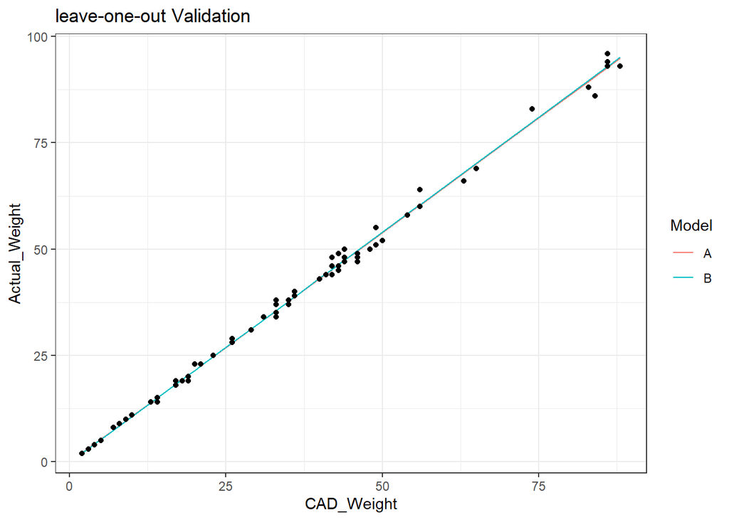

Subsequently, we examine the correlation between predicted scores and predictors. Notably, both scores exhibit a positive trend with increasing predictors, aligning with our model assumption.

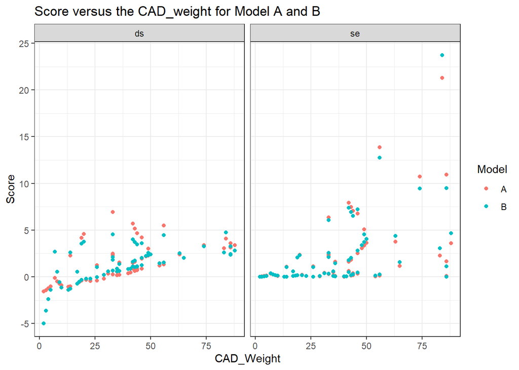

### 1.3.2 Average leave-one-out Score

For Model A, let $S(F_i^A, y_i)$ denote the score using prediction model $F_i$ on the new data $y_i$. Then, the average leave-one-out score $S_A$ has the formula:
$$S_A = \frac{1}{n}\sum_{i = 1}^n S(F_i^A, y_i)$$

Similarly, for Model B, the average leave-one-out score $S_B$ has the formula:
$$S_B = \frac{1}{n}\sum_{i = 1}^n S(F_i^B, y_i)$$

```r
result_summary <- result.leave1out %>%
  group_by(Model) %>%
  summarise(
    se = mean(se),
    ds = mean(ds)
  )
```

| Model | se | ds |
| --- | --- | --- |
| A | 1.841734 | 1.128348 |
| B | 1.841995 | 0.939715 |

Once again, we employ a scatter plot to examine the scores of the predicted values, highlighting the recently obtained averages.

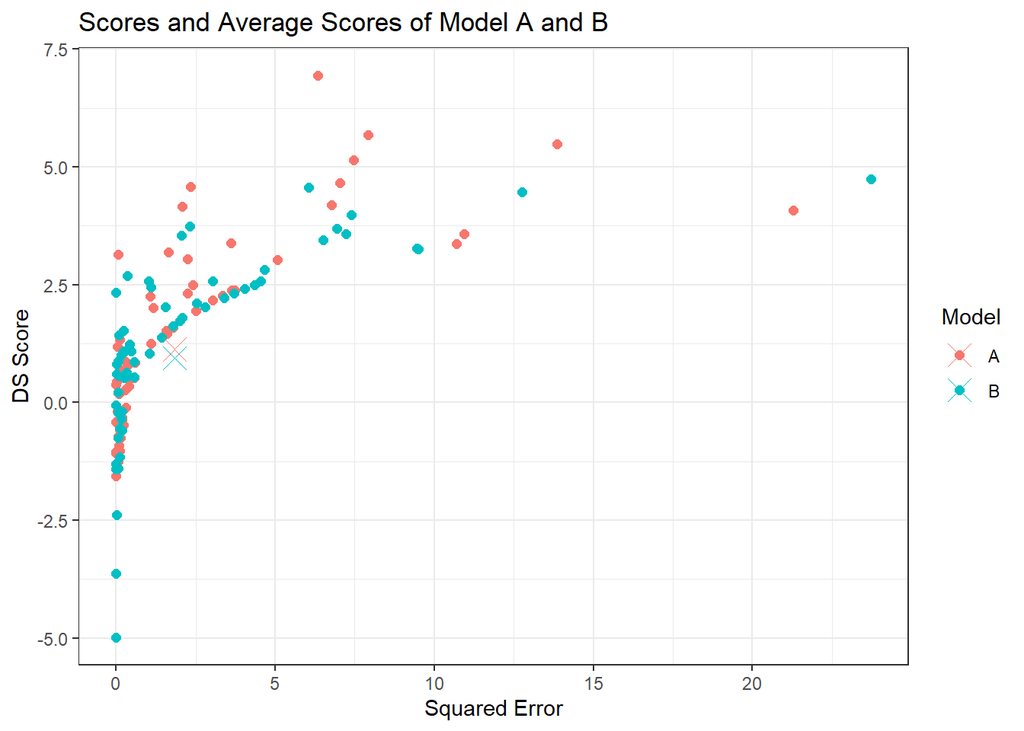

The results suggest that the mean square error of both models is comparable, indicating similar prediction accuracy between them. However, model B exhibits a smaller DS score. This reduction in DS score is attributed to the incorporation of variance alongside mean square error, highlighting the lower uncertainty associated with model B.

## 1.4 Question 4

### 1.4.1 Monte Carlo p-value Estimation

Our hypothesis for Model A and Model B is:
$$H_0: \text{A and B have pairwise exchangeability} \text{ v.s. } H_1:
\text{B is better than A}$$

For testing the average difference, we can use test statistic:
$$T = \frac{1}{n}\sum_{i=1}^{n} S_i^{\Delta},$$

where $S_i^{\Delta} = S(F_i^A, y_i) - S(F_i^B, y_i)$.

We now can use Monte Carlo Method to simulate the distribution of $T$. For each $j = 1, \dots, J$, we randomly swap the sign of $S_i^{\Delta}$, that is $\mathbb{P}\{S_i^{\Delta (j)} = S_i^{\Delta}\} = \mathbb{P}\{S_i^{\Delta (j)} = -S_i^{\Delta}\} = \frac{1}{2}$. We then compute test statistic:
$$T^{(j)} = \frac{1}{n}\sum_{i=1}^{n} S_i^{\Delta (j)}, j = 1, \dots, J.$$

According to the theory of Monte Carlo Probability Computation, we have an unbiased estimator of the p-value for testing our hypothesis:
$$\hat{p}_{value} = \frac{1}{J} \sum_{j = 1}^J \mathbb{1} \{ T^{(j)}
\ge T \}.$$

Let $J = 10000$.

```r
# S_Delta for each prediction
score_diff <- data.frame(
  se = result_A.leave1out$se - result_B.leave1out$se,
  ds = result_A.leave1out$ds - result_B.leave1out$ds
)

# test statistic
statistic0 <- score_diff %>%
  summarise(
    se = mean(se),
    ds = mean(ds)
  )

# sample number
J <- 10000

# sampling
statistic <- data.frame(
  se = numeric(J),
  ds = numeric(J)
)

for (loop in seq_len(J)) {
  random_sign <- sample(
    x = c(-1, 1),
    size = nrow(score_diff),
    replace = TRUE
  )
  statistic[loop, ] <- score_diff %>% summarise(
    se = mean(random_sign * se),
    ds = mean(random_sign * ds)
  )
}

# p-value computation
p_values <-
  statistic %>%
  summarise(
    se = mean(se > statistic0$se),
    ds = mean(ds > statistic0$ds)
  )
```

|  | se | ds |
| --- | --- | --- |
| p-value | 0.4989 | 0.0436 |

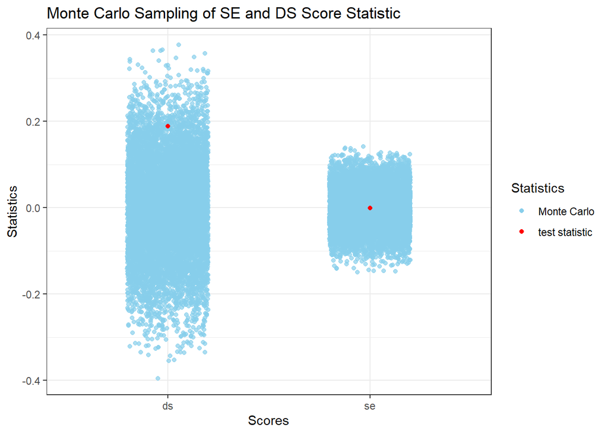

### 1.4.2 Monte Carlo Standard Error

Standard Error is the standard deviation of sample mean $\bar{X}$, then Monte Carlo standard error has the formula:
$$\hat{\sigma}_{\bar{X}} = \frac{\hat{\sigma}_X}{\sqrt{J}}$$

Monte Carlo Standard Error of test statistics $T$:

```r
standard.error.T <- data.frame(
  se = sd(statistic$se) / sqrt(J),
  ds = sd(statistic$ds) / sqrt(J)
)
```

|  | se | ds |
| --- | --- | --- |
| Standard Error | 0.0004726 | 0.0011228 |

Monte Carlo Standard Error of p-value estimator $p_{value}= \mathbb{1} \{ T^{(j)} \ge T \}$:

```r
standard.error.P <- data.frame(
  se = sd(statistic$se > statistic0$se) / sqrt(J),
  ds = sd(statistic$ds > statistic0$ds) / sqrt(J)
)
```

|  | se | ds |
| --- | --- | --- |
| Standard Error | 0.0050002 | 0.0020421 |

The small standard errors observed in both samples and p-value estimators generated by our Monte Carlo method suggest that our generated samples and p-value estimators closely resemble the population. This implies a high reliability of the obtained p-values.

Based on the p-value results for the squared errors of the two models, we infer that the two models exhibit pairwise exchangeability. However, when considering the DS scores, it appears that the performance of model B surpasses that of model A.

Taking into account the definitions of squared error and DS score, we can conclude that both model A and model B demonstrate similar levels of accuracy. Nonetheless, model B’s predictions exhibit higher certainty.

# 2 Part 2: Archaeology in the Baltic sea

## 2.1 Question 1

We assume that $Y$ is from Binominal distribution with parameters $N, \phi$:
$$Y \sim \text{Bino}(N, \phi), p_Y(y|N, \phi) = \left(\begin{matrix} N \\
y \end{matrix} \right) \phi^y (1 - \phi)^{N - y}.$$

Suppose we have 2 samples $y_1$ drawn from $Y_1$ and $y_2$ drawn from $Y_2$. Then, we can compute the log-likelihood given by parameters:
$$\begin{aligned}
\log [p(\boldsymbol{y}|N, \phi)] = \log [p(y_1, y_2|N, \phi)] = &
-\log \Gamma\left(y_{1}+1\right)-\log \Gamma\left(y_{2}+1\right) \\
& -\log \Gamma\left(N-y_{1}+1\right)-\log
\Gamma\left(N-y_{2}+1\right)+2 \log \Gamma(N+1) \\
& +\left(y_{1}+y_{2}\right) \log (\phi)+\left(2 N-y_{1}-y_{2}\right)
\log (1-\phi).
\end{aligned}$$

Hence we have the prior distribution:
$$\begin{aligned}
p_{N}(n)=\mathrm{P}(N=n) & =\xi(1-\xi)^{n}, \quad \xi =
\frac{1}{1001}, n=0,1,2,3, \ldots, \\
p_{\phi}(\phi) & =\frac{\phi^{a-1}(1-\phi)^{b-1}}{B(a, b)}, \quad a
= 2, b = 2, \phi \in[0,1] .
\end{aligned}$$

Note that we have the observations $\boldsymbol{y} = (256, 237)$ and let sample number $k = 100$:

```r
# sample number
k <- 100

# sampling
N.sample <- rgeom(n = k, prob = 1 / (1001))
Phi.sample <- rbeta(n = k, shape1 = 2, shape2 = 2)
params <- data.frame(
  N = N.sample,
  Phi = Phi.sample
)

# loglike
loglike <- arch_loglike(
  y = c(256, 237),
  params = params
)
```

| N | Phi | loglike |
| --- | --- | --- |
| 872 | 0.7769891 | -970.5908 |
| 1 | 0.7757799 | -Inf |
| 203 | 0.2276955 | -Inf |
| 2407 | 0.4452795 | -1362.5515 |
| 2523 | 0.2449088 | -365.5170 |
| 1731 | 0.4507126 | -762.3259 |

## 2.2 Question 2

Note that the posterior probability function for $(N, \phi \mid y)$ is:
$$p_{N, \phi \mid \boldsymbol{Y}}(n, \phi \mid \boldsymbol{y}) =
\frac{p_{N, \phi, \boldsymbol{Y}}(n, \phi,
\boldsymbol{y})}{p_{\boldsymbol{Y}}(\boldsymbol{y})} =
\frac{p_{N}(n) p_{\phi}(\phi) p(\boldsymbol{y} \mid n,
\phi)}{p_{\boldsymbol{Y}}(\boldsymbol{y})}.$$

Consider the prior distributions as sampling distributions, then the samples can be used to compute Monte Carlo estimations:
$$\begin{aligned}
\widehat{p}_{\boldsymbol{Y}}(\boldsymbol{y}) & =\frac{1}{K}
\sum_{k=1}^{K} p\left(\boldsymbol{y} \mid n^{[k]}, \phi^{[k]}\right) \\
\widehat{\mathrm{E}}(N \mid \boldsymbol{y}) & =\frac{1}{K
\widehat{p}_{\boldsymbol{Y}}(\boldsymbol{y})} \sum_{k=1}^{K} n^{[k]}
p\left(\boldsymbol{y} \mid n^{[k]}, \phi^{[k]}\right) \\
\widehat{\mathrm{E}}(\phi \mid \boldsymbol{y}) & =\frac{1}{K
\widehat{p}_{\boldsymbol{Y}}(\boldsymbol{y})} \sum_{k=1}^{K} \phi^{[k]}
p\left(\boldsymbol{y} \mid n^{[k]}, \phi^{[k]}\right)
\end{aligned}$$

```r
MC.estimation <- estimate(
  y = c(256, 237),
  xi = 1 / 1001,
  a = 0.5, b = 0.5,
  K = 10000
)
```

| p.y | E.N_y | E.Phi_y |
| --- | --- | --- |
| 8.3e-06 | 860.7398 | 0.426275 |

It’s important to note that the value of the density function holds no practical significance, as its estimator primarily serves as an expectation used for estimating the posterior distribution of two parameters.

# 3 Code appendix

```r
#' Ken Deng, s2617343
#' Add your own function definitions on this file.

#' neg_log_lik
#
#' @description Evaluate the negated log-likelihood for model A and B
#' @param beta A vector with the beta parameters
#' @param data A `data.frame` with the same variables as the `filament1` data set.
#' Must have columns `CAD_Weight` and `Actual_Weight`
#' @param model Either "A" for a log-linear variance model, or "B" for a proportional
#' scaling error model

neg_log_lik <- function(beta, data, model) {
  mu <- beta[1] + beta[2] * data[["CAD_Weight"]]

  # distinguish between the two models to find the particular standard deviation for the betas
  if (model == "A") {
    sigma <- sqrt(exp(beta[3] + beta[4] * data[["CAD_Weight"]]))
  } else {
    sigma <- sqrt(exp(beta[3]) + exp(beta[4]) * (data[["CAD_Weight"]]^2))
  }
  -sum(dnorm(data[["Actual_Weight"]],
    mean = mu,
    sd = sigma,
    log = TRUE
  ))
}

#' filament_estimate
#
#' @description Estimate filament models with different variance structure
#' @param data A `data.frame` with the same variables as the `filament1` data set.
#' Must have columns `CAD_Weight` and `Actual_Weight`
#' @param model Either "A" for a log-linear variance model, or "B" for a proportional
#' scaling error model
#' @return An estimation object suitable for use with [filament1_predict()]

filament1_estimate <- function(data, model) {
  model <- match.arg(model, c("A", "B"))
  if (model == "A") {
    beta_start <- c(-0.1, 1.07, -2, 0.05)
  } else {
    beta_start <- c(-0.15, 1.07, -13.5, -6.5)
  }
  opt <- optim(beta_start,
    neg_log_lik,
    data = data,
    model = model,
    hessian = TRUE,
    method = "Nelder-Mead",
    control = list(maxit = 5000)
  )
  fit <- list(
    model = model,
    par = opt$par,
    hessian = opt$hessian
  )
  class(fit) <- c("filament1_estimate", "list")
  fit # betahat and SEbetahat
}

#' filament1_aux_EV
#'
#' @description Evaluate the expectation and variance for model A and B
#' @param beta A vector with the beta parameters
#' @param data A `data.frame` containing the required predictors, including `CAD_Weight`
#' @param model Either "A" for a log-linear variance model, or "B" for a proportional
#' scaling error model
#' @param Sigma_beta : If not NULL, an estimate of the covariance matrix for
#                 the uncertainty of estimated betas
#' @return A list with four elements:
#     E : E(y|beta,x)
#     V : Var(y|beta,x)
#     VE : Var(E(y|beta,x)|x) or NULL
#     EV : E(Var(y|beta,x)|x) or NULL

filament1_aux_EV <- function(beta, data, model = c("A", "B"),
                             Sigma_beta = NULL) {
  model <- match.arg(model)
  if (model == "A") {
    ZE.0 <- model.matrix(~ 1 + CAD_Weight, data = data)
    ZV.0 <- model.matrix(~ 1 + CAD_Weight, data = data)
    ZE <- cbind(ZE.0, ZV.0 * 0)
    ZV <- cbind(ZE.0 * 0, ZV.0)

    VE <- EV <- NULL
    if (!is.null(Sigma_beta)) {
      # E(Var(y|beta,x)|x)
      EV <- exp(ZV %*% beta + rowSums(ZV * (ZV %*% Sigma_beta)) / 2)
      # Var(E(y|beta,x)|x)
      VE <- rowSums(ZE * (ZE %*% Sigma_beta))
    }
    out <- list(
      E = ZE %*% beta, # [X, 0] %*% betahat --- muhat_i
      V = exp(ZV %*% beta), # exp([0, X] %*% betahat) --- sigmahat_i residual variance
      VE = VE,
      EV = EV
    )
  } else { # model B

    ZE.0 <- model.matrix(~ 1 + CAD_Weight, data = data) # X
    ZV.0 <- model.matrix(~ 1 + I(CAD_Weight^2), data = data) # X
    ZE <- cbind(ZE.0, ZV.0 * 0)
    ZV <- cbind(ZE.0 * 0, ZV.0)

    VE <- EV <- NULL
    if (!is.null(Sigma_beta)) {
      # E(Var(y|beta,x)|x)
      # (pmin: Ignore large Sigma_beta values)
      EV <- ZV %*% exp(beta + pmin(0.5^2, diag(Sigma_beta)) / 2)
      # Var(E(y|beta,x)|x)
      VE <- rowSums(ZE * (ZE %*% Sigma_beta))
    }
    out <- list(
      E = ZE %*% beta,
      V = ZV %*% exp(beta),
      VE = VE,
      EV = EV
    )
  }
  out # hat E() and hat Var(), hat Var() of hat mu for each y_i
}

#' filament1_predict
#'
#' @description Evaluate the prediction means, standard deviations, and 95% PI
#' @param data train data
#' @param model the linear Model A or B
#' @param newdata test data
#' @return data.frame with mean, sd, lower bound, upper bound for test data

filament1_predict <- function(data, model, newdata) {
  # fit the model
  fit0 <- filament1_estimate(data = data, model = model)
  # prediction on test data
  pred0 <- filament1_aux_EV(
    beta = fit0$par,
    data = newdata,
    model = model,
    Sigma_beta = solve(fit0$hessian)
  )

  # prediction distribution
  mean <- pred0$E
  sd <- sqrt(pred0$EV + pred0$VE)
  q <- qt(1 - 0.05 / 2, df = Inf)
  lwr <- mean - q * sd
  upr <- mean + q * sd

  # return
  data.frame(
    mean = mean, sd = sd,
    lwr = lwr, upr = upr
  )
}

#' filament1_score
#'
#' @description Evaluate the squared error (ES) and Dawid-Sebastiani (DS) scores.
#' @param data train data
#' @param model the linear Model A or B
#' @param newdata test data
#' @return data.frame that extends the original data frame with additional columns:
#'         mean, sd, lower bound, upper bound, se and ds of prediction distribution and prediction scores.

filament1_score <- function(data, model, newdata) {
  # fit the model and predict the test data
  pred <- filament1_predict(
    data = data,
    model = model,
    newdata = newdata
  )

  # calculate the score for each prediction
  result <- cbind(newdata, pred) %>%
    mutate(
      se = (Actual_Weight - mean)^2,
      ds = (Actual_Weight - mean)^2 / sd^2 + 2 * log(sd)
    )

  # return
  result
}

#' leave1out
#'
#' @description leave-one-out cross-validation for the selected model for each observation
#' @param data dataset
#' @param model model the linear Model A or B
#' @return data.frame that extends the original data frame with four additional columns:
#'         mean, sd, se and ds of leave-one-out prediction means, standard deviations, and prediction scores.

leave1out <- function(data, model) {
  n <- nrow(data)
  mean <- numeric(n)
  sd <- numeric(n)

  for (i in 1:n) {
    # train data
    leave_1_out_data <- data[-i, ]

    # fit the model and predict the test data
    fit0 <- filament1_estimate(
      data = leave_1_out_data,
      model = model
    )
    pred0 <- filament1_aux_EV(
      beta = fit0$par,
      data = data[i, ],
      model = model,
      Sigma_beta = solve(fit0$hessian)
    )

    # prediction distribution
    mean[i] <- pred0$E
    sd[i] <- sqrt(pred0$EV + pred0$VE)
  }

  pred.dist <- data.frame(
    mean = mean, sd = sd
  )

  result <- cbind(data, pred.dist) %>%
    mutate(
      se = (Actual_Weight - mean)^2,
      ds = (Actual_Weight - mean)^2 / (sd)^2 + 2 * log(sd)
    )

  # return
  result
}

#' arch_loglike
#'
#' @description Evaluates the combined log-likelihood for a collection y-observations.
#' @param y y-observations
#' @param params data.frame with columns samples N and phi
#' @return the log-likelihood for each row-pair (N, phi)

arch_loglike <- function(y, params) {
  y1 <- y[1]
  y2 <- y[2]
  N <- params$N
  Phi <- params$Phi

  # return loglike
  -lgamma(y1 + 1) - lgamma(y2 + 1) - lgamma(N - y1 + 1) - lgamma(N - y2 + 1) +
    2 * lgamma(N + 1) + (y1 + y2) * log(Phi) + (2 * N - y1 - y2) * log(1 - Phi)
}

#' estimate
#'
#' @description Monte Carlo integration method to approximate p(y), E(N|y), and E(phi|y).
#' @param y y-observations
#' @param xi parameter of N prior distribution
#' @param a parameter of phi prior distribution
#' @param b parameter of phi prior distribution
#' @param K number of samples
#' @return estimations for p(y), E(N|y), and E(phi|y)

estimate <- function(y, xi, a, b, K) {
  # sampling
  N <- rgeom(n = K, prob = xi)
  Phi <- rbeta(n = K, shape1 = a, shape2 = b)
  params <- data.frame(N = N, Phi = Phi)
  likelihood <- exp(arch_loglike(y = y, params = params))

  # compute estimation
  density_y <- 1 / (K) * (sum(likelihood))
  expectation_N <- 1 / (K * density_y) * (sum(N * likelihood))
  expectation_Phi <- 1 / (K * density_y) * (sum(Phi * likelihood))

  # return
  data.frame(p.y = density_y, E.N_y = expectation_N, E.Phi_y = expectation_Phi)
}
```